# How can a wellness company play it smart?

Abdelhaleem ZIDAN

2022-09-13

### Bussiness Task

Is to analyze smart wearable device usage patterns and trends in order to gain some insights to analyse and improve **BellaBeat** products performance. which can improve our services and products from the technical prespictive and from the marketing prespective.

### Discription of the data source

Primary data exploration was done using excel, and the data consists of mainly 5 categories:

- daily calories
- daily steps
- daily intensities - *the 3 of them are already merged in one dataset* **dailyActivity_merged** with total of 33 participants
- heart rate - *data for only 7 participants it will be insufficient to use*
- weight log info. - *data for only 8 participants it will be insufficient to use*
- Sleep per day. - *24 participants*

> the rest of the csvs are for the same categories above but with more granular information (per hour and per minute), we will be focusing mainly on daily data for our analysis. from the granulated data we will focus only on the following:
- hourly calories
- hourly steps

### transforming and cleaning

I chose to use R because I need to document and share the whole process on my portofolio and because excel cannot handle very large datasets. and for my personal interest because i need to practice more R as it will be my first complete project to execute with R.

#### installing and importing packages

```r
install.packages("tidyverse",repos = "http://cran.us.r-project.org")
install.packages("ggplot2",repos = "http://cran.us.r-project.org")
install.packages("skimr",repos = "http://cran.us.r-project.org")
install.packages("janitor",repos = "http://cran.us.r-project.org")
```

```r
library(tidyverse)
library(ggplot2)
library(skimr)
library(janitor)
library(lubridate)
library(dplyr)
```

#### importing data

```r
daily_activity <- read_csv("~/Documents/work/Data Analysis/202209_Capstone project for Google certificate/202209_Case-study_BellaBeats_Google/2022_case-study_google-certificate_BellaBeat/dailyActivity_merged.csv")
sleep_day <- read_csv("~/Documents/work/Data Analysis/202209_Capstone project for Google certificate/202209_Case-study_BellaBeats_Google/2022_case-study_google-certificate_BellaBeat/sleepDay_merged.csv")
hourly_calories <- read_csv("~/Documents/work/Data Analysis/202209_Capstone project for Google certificate/202209_Case-study_BellaBeats_Google/2022_case-study_google-certificate_BellaBeat/hourlyCalories_merged.csv")
hourly_steps <- read_csv("~/Documents/work/Data Analysis/202209_Capstone project for Google certificate/202209_Case-study_BellaBeats_Google/2022_case-study_google-certificate_BellaBeat/hourlySteps_merged.csv")
```

#### verifying correct importation of data and getting more insights on it

we can use different functions to explore our data like (skim, str, head, view, …etc)

```r
summary(daily_activity)
```

```
##        Id            ActivityDate         TotalSteps    TotalDistance
##  Min.   :1.504e+09   Length:940         Min.   :    0   Min.   : 0.000
##  1st Qu.:2.320e+09   Class :character   1st Qu.: 3790   1st Qu.: 2.620
##  Median :4.445e+09   Mode  :character   Median : 7406   Median : 5.245
##  Mean   :4.855e+09                      Mean   : 7638   Mean   : 5.490
##  3rd Qu.:6.962e+09                      3rd Qu.:10727   3rd Qu.: 7.713
##  Max.   :8.878e+09                      Max.   :36019   Max.   :28.030
##  TrackerDistance  LoggedActivitiesDistance VeryActiveDistance
##  Min.   : 0.000   Min.   :0.0000           Min.   : 0.000
##  1st Qu.: 2.620   1st Qu.:0.0000           1st Qu.: 0.000
##  Median : 5.245   Median :0.0000           Median : 0.210
##  Mean   : 5.475   Mean   :0.1082           Mean   : 1.503
##  3rd Qu.: 7.710   3rd Qu.:0.0000           3rd Qu.: 2.053
##  Max.   :28.030   Max.   :4.9421           Max.   :21.920
##  ModeratelyActiveDistance LightActiveDistance SedentaryActiveDistance
##  Min.   :0.0000           Min.   : 0.000      Min.   :0.000000
##  1st Qu.:0.0000           1st Qu.: 1.945      1st Qu.:0.000000
##  Median :0.2400           Median : 3.365      Median :0.000000
##  Mean   :0.5675           Mean   : 3.341      Mean   :0.001606
##  3rd Qu.:0.8000           3rd Qu.: 4.782      3rd Qu.:0.000000
##  Max.   :6.4800           Max.   :10.710      Max.   :0.110000
##  VeryActiveMinutes FairlyActiveMinutes LightlyActiveMinutes SedentaryMinutes
##  Min.   :  0.00    Min.   :  0.00      Min.   :  0.0        Min.   :   0.0
##  1st Qu.:  0.00    1st Qu.:  0.00      1st Qu.:127.0        1st Qu.: 729.8
##  Median :  4.00    Median :  6.00      Median :199.0        Median :1057.5
##  Mean   : 21.16    Mean   : 13.56      Mean   :192.8        Mean   : 991.2
##  3rd Qu.: 32.00    3rd Qu.: 19.00      3rd Qu.:264.0        3rd Qu.:1229.5
##  Max.   :210.00    Max.   :143.00      Max.   :518.0        Max.   :1440.0
##     Calories
##  Min.   :   0
##  1st Qu.:1828
##  Median :2134
##  Mean   :2304
##  3rd Qu.:2793
##  Max.   :4900
```

```r
summary(sleep_day)
```

```
##        Id              SleepDay         TotalSleepRecords TotalMinutesAsleep
##  Min.   :1.504e+09   Length:413         Min.   :1.000     Min.   : 58.0
##  1st Qu.:3.977e+09   Class :character   1st Qu.:1.000     1st Qu.:361.0
##  Median :4.703e+09   Mode  :character   Median :1.000     Median :433.0
##  Mean   :5.001e+09                      Mean   :1.119     Mean   :419.5
##  3rd Qu.:6.962e+09                      3rd Qu.:1.000     3rd Qu.:490.0
##  Max.   :8.792e+09                      Max.   :3.000     Max.   :796.0
##  TotalTimeInBed
##  Min.   : 61.0
##  1st Qu.:403.0
##  Median :463.0
##  Mean   :458.6
##  3rd Qu.:526.0
##  Max.   :961.0
```

```r
skim(hourly_calories)
```

Data summary

| Name | hourly_calories |
| --- | --- |
| Number of rows | 22099 |
| Number of columns | 3 |
| _______________________ |  |
| Column type frequency: |  |
| character | 1 |
| numeric | 2 |
| ________________________ |  |
| Group variables | None |

**Variable type: character**

| skim_variable | n_missing | complete_rate | min | max | empty | n_unique | whitespace |
| --- | --- | --- | --- | --- | --- | --- | --- |
| ActivityHour | 0 | 1 | 19 | 21 | 0 | 736 | 0 |

**Variable type: numeric**

| skim_variable | n_missing | complete_rate | mean | sd | p0 | p25 | p50 | p75 | p100 | hist |
| --- | --- | --- | --- | --- | --- | --- | --- | --- | --- | --- |
| Id | 0 | 1 | 4.848235e+09 | 2.4225e+09 | 1503960366 | 2320127002 | 4445114986 | 6962181067 | 8877689391 | ▇▅▃▅▅ |
| Calories | 0 | 1 | 9.739000e+01 | 6.0700e+01 | 42 | 63 | 83 | 108 | 948 | ▇▁▁▁▁ |

```r
skim(hourly_steps)
```

Data summary

| Name | hourly_steps |
| --- | --- |
| Number of rows | 22099 |
| Number of columns | 3 |
| _______________________ |  |
| Column type frequency: |  |
| character | 1 |
| numeric | 2 |
| ________________________ |  |
| Group variables | None |

**Variable type: character**

| skim_variable | n_missing | complete_rate | min | max | empty | n_unique | whitespace |
| --- | --- | --- | --- | --- | --- | --- | --- |
| ActivityHour | 0 | 1 | 19 | 21 | 0 | 736 | 0 |

**Variable type: numeric**

| skim_variable | n_missing | complete_rate | mean | sd | p0 | p25 | p50 | p75 | p100 | hist |
| --- | --- | --- | --- | --- | --- | --- | --- | --- | --- | --- |
| Id | 0 | 1 | 4.848235e+09 | 2.4225e+09 | 1503960366 | 2320127002 | 4445114986 | 6962181067 | 8877689391 | ▇▅▃▅▅ |
| StepTotal | 0 | 1 | 3.201700e+02 | 6.9038e+02 | 0 | 0 | 40 | 357 | 10554 | ▇▁▁▁▁ |

```r
n_unique(daily_activity$Id)
```

```
## [1] 33
```

```r
n_unique(sleep_day$Id)
```

```
## [1] 24
```

```r
n_unique(hourly_calories$Id)
```

```
## [1] 33
```

```r
n_unique(hourly_steps$Id)
```

```
## [1] 33
```

> **The above exploration confirmed our initial findings from excel, we have a time frame of 31 days, participants for sleep data are ony 24 and for other data are 33 so we will need to be careful if we are merging those 2 datasets not to lose the unmatched ids from the daily activity data. no null values observed in the datasets.** **It also shows the average sleep min 419 (6.9 hours), and the average very active min is 21 which can be improved**

#### Cleaning and Transforming

We need to clean and transform the dates datasets as some are in datetime and all need to be standardized.

```r
daily_activity$ActivityDate <- mdy(daily_activity$ActivityDate)
```

```r
sleep_day$SleepDay <- mdy_hms(sleep_day$SleepDay)
```

```r
hourly_calories$ActivityHour <- mdy_hms(hourly_calories$ActivityHour)
```

```r
hourly_steps$ActivityHour <- mdy_hms(hourly_steps$ActivityHour)
```

next we are going to clean column names

```r
daily_activity_c <- daily_activity %>%
  clean_names()
sleep_day_c <- sleep_day %>%
  clean_names() %>%
  rename(date = sleep_day)
hourly_calories_c <- hourly_calories %>%
  clean_names()
hourly_steps_c <- hourly_steps %>%
  clean_names()
```

#### Analysis & Visualization

first we will merge our datasets to link some data together to be able to do more analysis and vis.

##### Here will perform our first merge & separate date from time for the **hourly data**

```r
hourly_calories_steps <-
  merge(hourly_calories_c, hourly_steps_c)
hourly_calories_steps$date <- as.Date(hourly_calories_steps$activity_hour)
hourly_calories_steps$time <-
  format(as.POSIXct(hourly_calories_steps$activity_hour),format =  "%H:%M:%S")
```

Creating a column to categorize the time (morning, afternoon,evening, night)

```r
hourly_calories_steps <- hourly_calories_steps %>%
  mutate(part_of_day = case_when(
    time >  "05:00:00" & time <= "12:00:00"  ~ "Morning 5 to 12",
    time >  "12:00:00" & time <= "17:00:00"  ~ "Afternoon 12 to 17",
    time >  "17:00:00" & time <= "21:00:00"  ~ "Evening 17 to 21",
    TRUE ~ "night 21 to 5"))
```

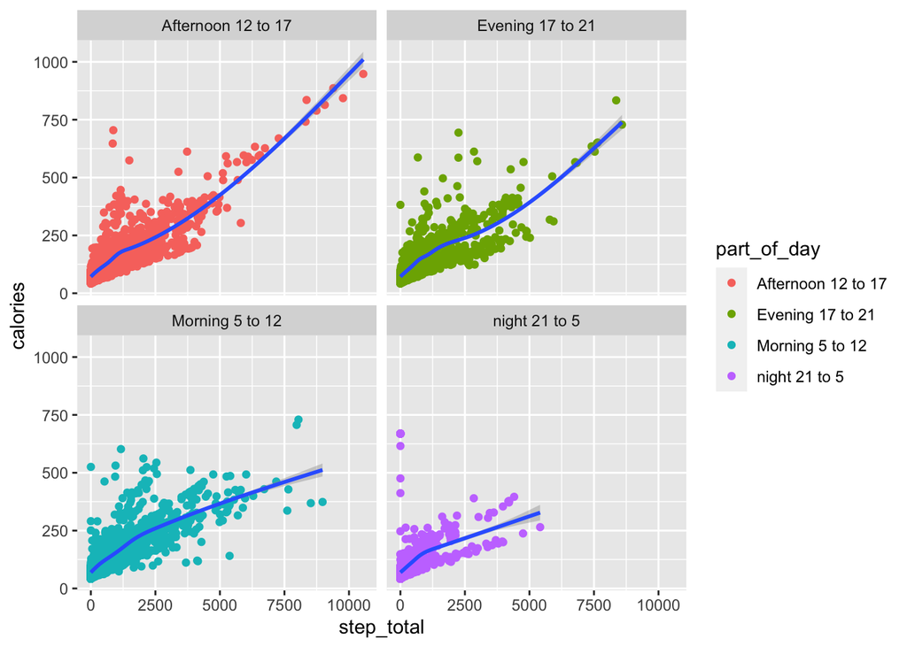

```r
ggplot(hourly_calories_steps, aes(x = step_total, y = calories)) +
  geom_jitter(aes(color = part_of_day)) +
  geom_smooth() +
  facet_wrap(~part_of_day)
```

```r
  labs(title = "Total steps VS calories")
```

```
## $title
## [1] "Total steps VS calories"
##
## attr(,"class")
## [1] "labels"
```

> as expected there is a positive coorelation between the number of steps and the calories burnt. 🥵

plotting calories burnt over the day by all participants

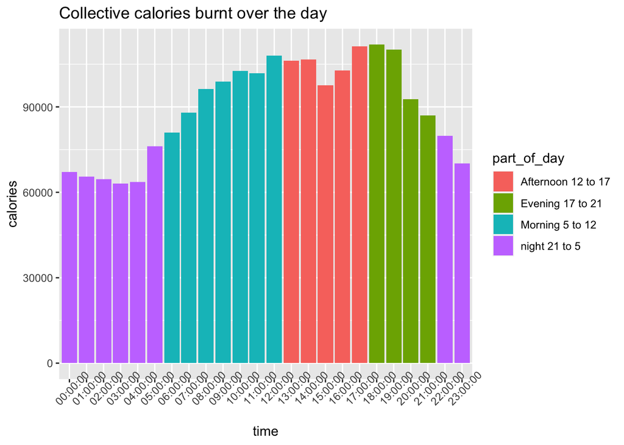

```r
ggplot(hourly_calories_steps, aes(x = time, y = calories, fill = part_of_day)) +
  geom_col()+
  labs(title = "Collective calories burnt over the day") +
  theme(axis.text.x = element_text(angle = 45))
```

> As expected the least calories was burnt during the night

##### Next merging **daily data**

```r
daily_activity_sleep <-
  merge(daily_activity_c, sleep_day_c,
        by.x = c("id","activity_date"), by.y = c("id","date"),
        all.x = TRUE, all.y = TRUE)
```

```r
skim(daily_activity_sleep)
```

Data summary

| Name | daily_activity_sleep |
| --- | --- |
| Number of rows | 943 |
| Number of columns | 18 |
| _______________________ |  |
| Column type frequency: |  |
| Date | 1 |
| numeric | 17 |
| ________________________ |  |
| Group variables | None |

**Variable type: Date**

| skim_variable | n_missing | complete_rate | min | max | median | n_unique |
| --- | --- | --- | --- | --- | --- | --- |
| activity_date | 0 | 1 | 2016-04-12 | 2016-05-12 | 2016-04-26 | 31 |

**Variable type: numeric**

| skim_variable | n_missing | complete_rate | mean | sd | p0 | p25 | p50 | p75 | p100 | hist |
| --- | --- | --- | --- | --- | --- | --- | --- | --- | --- | --- |
| id | 0 | 1.00 | 4.858486e+09 | 2.423712e+09 | 1503960366 | 2.320127e+09 | 4.445115e+09 | 6.962181e+09 | 8.877689e+09 | ▇▅▃▅▅ |
| total_steps | 0 | 1.00 | 7.652190e+03 | 5.086530e+03 | 0 | 3.795000e+03 | 7.439000e+03 | 1.073400e+04 | 3.601900e+04 | ▇▇▁▁▁ |
| total_distance | 0 | 1.00 | 5.500000e+00 | 3.930000e+00 | 0 | 2.620000e+00 | 5.260000e+00 | 7.720000e+00 | 2.803000e+01 | ▇▆▁▁▁ |
| tracker_distance | 0 | 1.00 | 5.490000e+00 | 3.910000e+00 | 0 | 2.620000e+00 | 5.260000e+00 | 7.710000e+00 | 2.803000e+01 | ▇▆▁▁▁ |
| logged_activities_distance | 0 | 1.00 | 1.100000e-01 | 6.200000e-01 | 0 | 0.000000e+00 | 0.000000e+00 | 0.000000e+00 | 4.940000e+00 | ▇▁▁▁▁ |
| very_active_distance | 0 | 1.00 | 1.500000e+00 | 2.660000e+00 | 0 | 0.000000e+00 | 2.200000e-01 | 2.060000e+00 | 2.192000e+01 | ▇▁▁▁▁ |
| moderately_active_distance | 0 | 1.00 | 5.700000e-01 | 8.800000e-01 | 0 | 0.000000e+00 | 2.400000e-01 | 8.100000e-01 | 6.480000e+00 | ▇▁▁▁▁ |
| light_active_distance | 0 | 1.00 | 3.350000e+00 | 2.050000e+00 | 0 | 1.950000e+00 | 3.380000e+00 | 4.790000e+00 | 1.071000e+01 | ▆▇▆▁▁ |
| sedentary_active_distance | 0 | 1.00 | 0.000000e+00 | 1.000000e-02 | 0 | 0.000000e+00 | 0.000000e+00 | 0.000000e+00 | 1.100000e-01 | ▇▁▁▁▁ |
| very_active_minutes | 0 | 1.00 | 2.124000e+01 | 3.295000e+01 | 0 | 0.000000e+00 | 4.000000e+00 | 3.200000e+01 | 2.100000e+02 | ▇▁▁▁▁ |
| fairly_active_minutes | 0 | 1.00 | 1.363000e+01 | 2.000000e+01 | 0 | 0.000000e+00 | 7.000000e+00 | 1.900000e+01 | 1.430000e+02 | ▇▁▁▁▁ |
| lightly_active_minutes | 0 | 1.00 | 1.930300e+02 | 1.093100e+02 | 0 | 1.270000e+02 | 1.990000e+02 | 2.640000e+02 | 5.180000e+02 | ▅▇▇▃▁ |
| sedentary_minutes | 0 | 1.00 | 9.903500e+02 | 3.012600e+02 | 0 | 7.290000e+02 | 1.057000e+03 | 1.229000e+03 | 1.440000e+03 | ▁▁▇▅▇ |
| calories | 0 | 1.00 | 2.307510e+03 | 7.208200e+02 | 0 | 1.829500e+03 | 2.140000e+03 | 2.796500e+03 | 4.900000e+03 | ▁▆▇▃▁ |
| total_sleep_records | 530 | 0.44 | 1.120000e+00 | 3.500000e-01 | 1 | 1.000000e+00 | 1.000000e+00 | 1.000000e+00 | 3.000000e+00 | ▇▁▁▁▁ |
| total_minutes_asleep | 530 | 0.44 | 4.194700e+02 | 1.183400e+02 | 58 | 3.610000e+02 | 4.330000e+02 | 4.900000e+02 | 7.960000e+02 | ▁▂▇▃▁ |
| total_time_in_bed | 530 | 0.44 | 4.586400e+02 | 1.271000e+02 | 61 | 4.030000e+02 | 4.630000e+02 | 5.260000e+02 | 9.610000e+02 | ▁▃▇▁▁ |

**note that we have 530 unmatched values from the missing data in the sleep_day dataset**

#### Grouping by ID to determine average distance covered vs average sedentary minutes vs calories

```r
grouped_d_a <- daily_activity_sleep %>%
  group_by(id) %>%
  summarise(average_very_active_m = mean(very_active_minutes), average_distance = mean(total_distance), average_sedentary = mean(sedentary_minutes), average_calories = mean(calories))
```

```r
summary(grouped_d_a)
```

```
##        id            average_very_active_m average_distance  average_sedentary
##  Min.   :1.504e+09   Min.   : 0.09677      Min.   : 0.6345   Min.   : 662.3
##  1st Qu.:2.347e+09   1st Qu.: 3.58065      1st Qu.: 3.4548   1st Qu.: 760.5
##  Median :4.445e+09   Median :10.38710      Median : 5.2953   Median :1077.5
##  Mean   :4.857e+09   Mean   :20.35331      Mean   : 5.4052   Mean   : 999.0
##  3rd Qu.:6.962e+09   3rd Qu.:23.41935      3rd Qu.: 7.0050   3rd Qu.:1206.6
##  Max.   :8.878e+09   Max.   :87.33333      Max.   :13.2129   Max.   :1317.4
##  average_calories
##  Min.   :1483
##  1st Qu.:1917
##  Median :2132
##  Mean   :2283
##  3rd Qu.:2600
##  Max.   :3454
```

#### Categorizing by activity level assuming that:

**high activity** are people who have average distance and average very active minutes **more** than the total average and sedentary minutes **less** than the total average sedentary time.

**low active** are people who have average distance and average very active minutes **less** than the total average and sedentary minutes **more** than the total. average sedentary time.

**moderately active** are people who doesn’t fall in either of the previous groups.

```r
grouped_d_a <- grouped_d_a %>%
  mutate(activity_level =
           case_when(
             average_very_active_m > mean(average_very_active_m) &
               average_distance > mean(average_distance) &
               average_sedentary < mean(average_sedentary) ~ "very active",
             average_very_active_m < mean(average_very_active_m) &
               average_distance < mean(average_distance) &
               average_sedentary > mean(average_sedentary) ~ "low active",
             TRUE ~ "moderately active"))
```

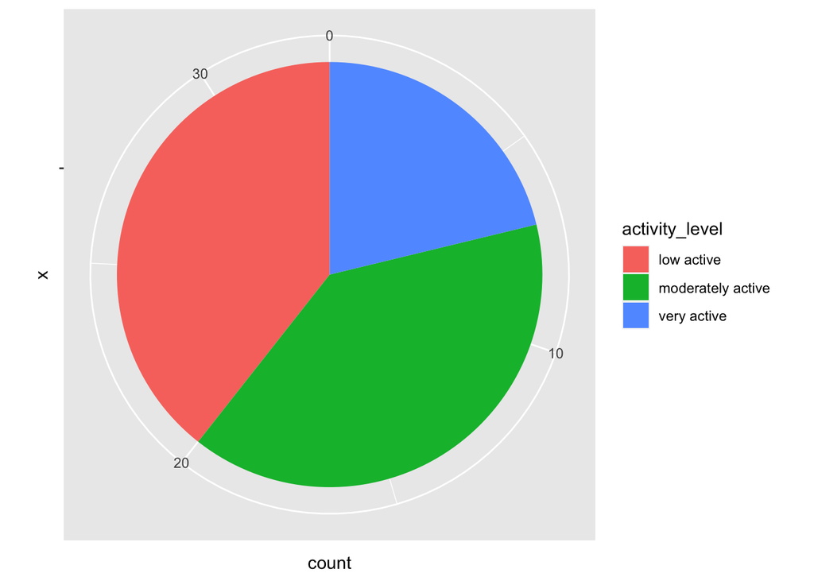

```r
ggplot(grouped_d_a,aes(x = "", Y = average_very_active_m)) +
  geom_bar(aes(fill = activity_level)) +
  coord_polar(theta = "y")
```

> AS we can more than 1 thirds of our sample are low active.

Then adding the activity level column to our **daily_activity_sleep**

```r
daily_activity_sleep <- grouped_d_a %>%
  select(id, activity_level) %>%
  left_join(daily_activity_sleep, grouped_d_a, by = "id")
```

now plotting total distance covered VS calories burnt by activity level

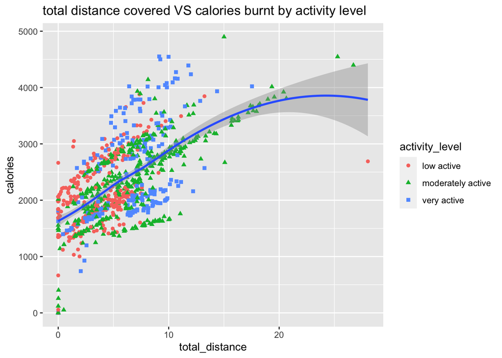

```r
ggplot(daily_activity_sleep, aes(x = total_distance, y = calories)) +
  geom_point(aes(color = activity_level, shape = activity_level)) +
  geom_smooth() +
  labs(title = "total distance covered VS calories burnt by activity level")
```

> We can see a positive coorlation between the distance covered and the total calories burnt, and also that very active people tend to burn more calories with less distance covred.

#### exploring if there is a coorelation between Sleep and calories or total steps respectively:

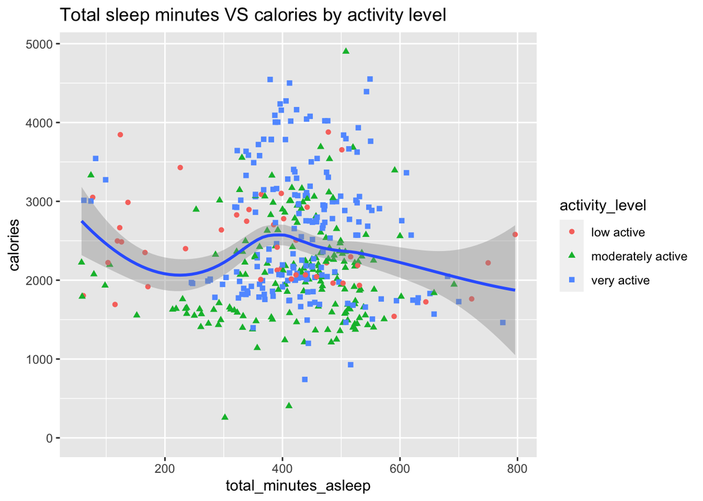

```r
ggplot(daily_activity_sleep, aes(x = total_minutes_asleep, y = calories)) +
  geom_point(aes(color = activity_level, shape = activity_level)) +
  geom_smooth() +
  labs(title = "Total sleep minutes VS calories by activity level")
```

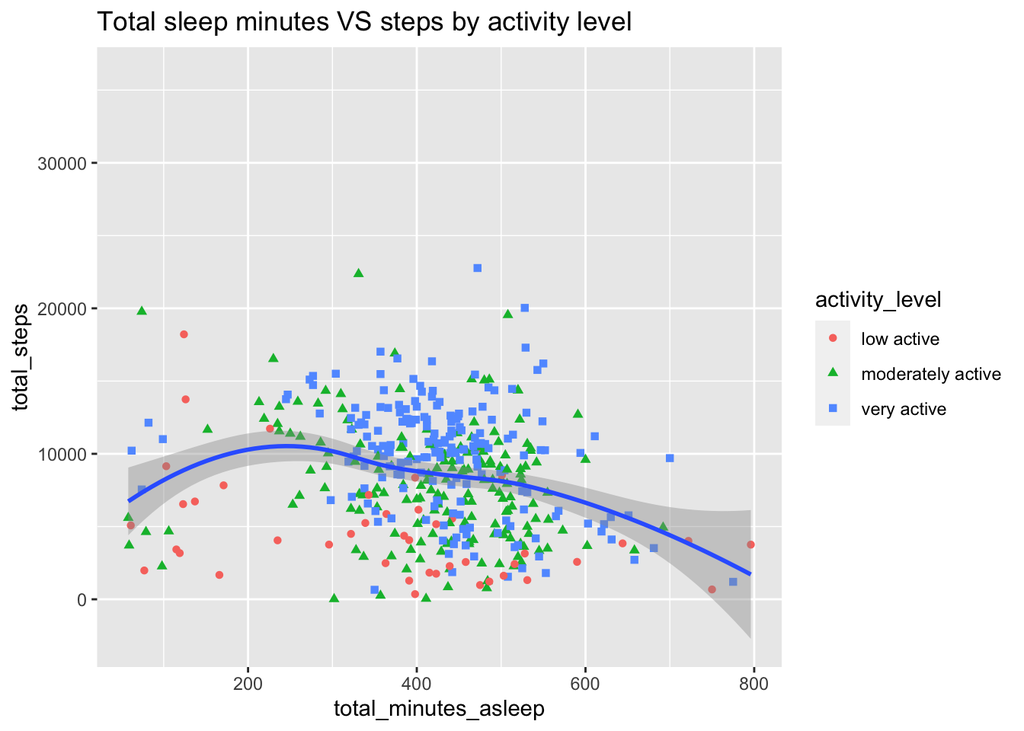

```r
ggplot(daily_activity_sleep, aes(x = total_minutes_asleep, y = total_steps)) +
  geom_point(aes(color = activity_level, shape = activity_level)) +
  geom_smooth() +
  labs(title = "Total sleep minutes VS steps by activity level")
```

> we can see no correlation between sleep and steps or calories burnt

### Act

> giving all of the above, we should take the results of the analysis very carefully, and further analysis with internal data from BellaBeat will be very important to confirm this analysis.

#### final recommendations:

1- Our Marketing strategy for **Leaf** and **Time** should focus on the importance of activity (minutes or steps) for burning calories and loosing weight, and the benefits of wearing our smart devices to record activities and setting goals and get reminded every day to reach your goal.

2- from our analysis we can recommend the following for better caloric burn:

- more than 20 minutes per day of high intensity activity.
- more than 5 kilometer of walking distance per day.
- less than 16 hours sedentary per day.

3- introduce some kind of trophy system to our app for people who keep reaching the daily goal for long time, this will encourage our customers to wear our products for longer periods, because of the sens of achivement that the could get from the trophy system.

> Thank you for reading, your feedback is most welcomed